# The House Prices: Advanced Regression Techniques

[The House Prices: Advanced Regression Techniques](https://www.kaggle.com/c/house-prices-advanced-regression-techniques/overview) was originally hosted on Kaggle.

[figure not shown]

# Description:

- Ask a home buyer to describe their dream house, and they probably won't begin with the height of the basement ceiling or the proximity to an east-west railroad. But this playground competition's dataset proves that much more influences price negotiations than the number of bedrooms or a white-picket fence.
- With 79 explanatory variables describing (almost) every aspect of residential homes in Ames, Iowa, this competition challenges you to predict the final price of each home.

# Practice Skills

- Creative feature engineering
- Advanced regression techniques like random forest and gradient boosting

# Acknowledgments

- The [Ames Dataset](http://jse.amstat.org/v19n3/decock.pdf) dataset was compiled by Dean De Cock for use in data science education. It's an incredible alternative for data scientists looking for a modernized and expanded version of the often cited Boston Housing dataset.

```python
# Imnporting libraries
import pandas as pd
import numpy as np
import matplotlib.pyplot as plt
import seaborn as sns
```

```python
# Reading the data
train_df = pd.read_csv('./Data/train.csv')
test_df = pd.read_csv('./Data/test.csv')
sample_submission = pd.read_csv('./Data/sample_submission.csv')
```

# EDA

- Let's get started with some Exploratory Data Analysis

## Let's try and get a sense of our data

```python
# Lets take a look at the dataset
train_df.head()
```

|  | Id | MSSubClass | MSZoning | LotFrontage | LotArea | Street | Alley | LotShape | LandContour | Utilities | ... | PoolArea | PoolQC | Fence | MiscFeature | MiscVal | MoSold | YrSold | SaleType | SaleCondition | SalePrice |
| --- | --- | --- | --- | --- | --- | --- | --- | --- | --- | --- | --- | --- | --- | --- | --- | --- | --- | --- | --- | --- | --- |
| 0 | 1 | 60 | RL | 65.0 | 8450 | Pave | NaN | Reg | Lvl | AllPub | ... | 0 | NaN | NaN | NaN | 0 | 2 | 2008 | WD | Normal | 208500 |
| 1 | 2 | 20 | RL | 80.0 | 9600 | Pave | NaN | Reg | Lvl | AllPub | ... | 0 | NaN | NaN | NaN | 0 | 5 | 2007 | WD | Normal | 181500 |
| 2 | 3 | 60 | RL | 68.0 | 11250 | Pave | NaN | IR1 | Lvl | AllPub | ... | 0 | NaN | NaN | NaN | 0 | 9 | 2008 | WD | Normal | 223500 |
| 3 | 4 | 70 | RL | 60.0 | 9550 | Pave | NaN | IR1 | Lvl | AllPub | ... | 0 | NaN | NaN | NaN | 0 | 2 | 2006 | WD | Abnorml | 140000 |
| 4 | 5 | 60 | RL | 84.0 | 14260 | Pave | NaN | IR1 | Lvl | AllPub | ... | 0 | NaN | NaN | NaN | 0 | 12 | 2008 | WD | Normal | 250000 |

5 rows × 81 columns

```python
train_df.shape
```

```
(1460, 81)
```

- Seems we have 1460 observations and 79 features (if we exlcude ID and Dependent variable i.e. SalePrice)

## Let's see how our dependant variable looks

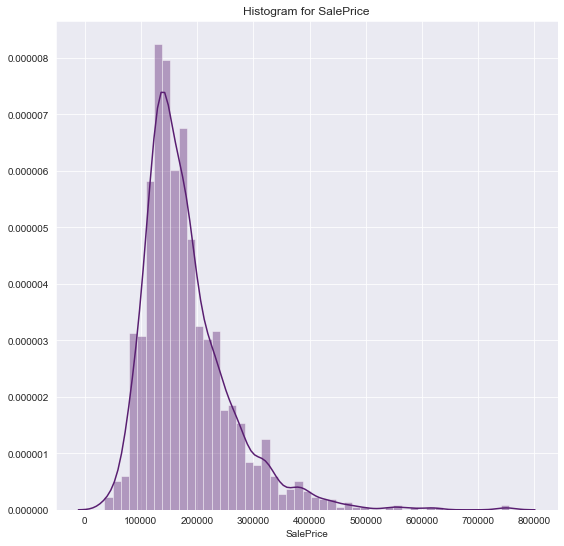

```python
# Setting the grid style
sns.set_style('darkgrid')
sns.set_color_codes(palette='dark')

# Setting plot area
f, ax = plt.subplots(figsize=(9, 9))

# plotting the distribution plot
sns.distplot(train_df['SalePrice'], color="m", axlabel='SalePrice')
ax.set(title="Histogram for SalePrice")
plt.show()
```

- Seems like SalePrice is right skewed and we will have to normalize it.

## Let's vizualize the correlation matrix

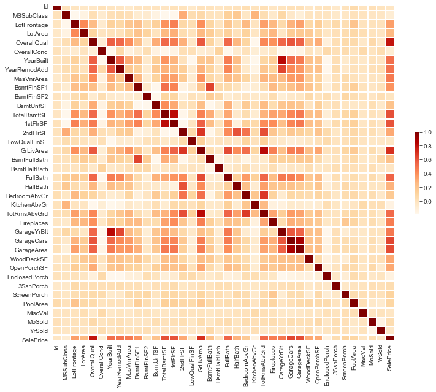

```python
# Calc correlation matrix
corr_mat = train_df.corr()

# Set plot size
plt.subplots(figsize=(12,10))

# Plot heatmap
sns.heatmap(corr_mat,
            square=True,
            robust=True,
            cmap='OrRd', # use orange/red colour map
            cbar_kws={'fraction' : 0.01}, # shrink colour bar
            linewidth=1) # space between cells
```

### Zoomed in Correlation Matrix

- Let's vizualize only the variables with high correlation coefficient.

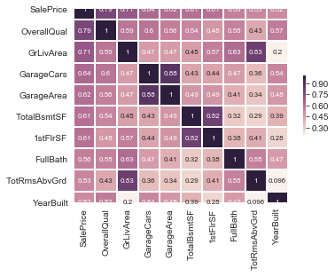

```python
# number of variables we want on the heatmap
k = 10

# Filter in the Top k variables with highest correlation with SalePrice
cols = corr_mat.nlargest(k, 'SalePrice')['SalePrice'].index
cm = np.corrcoef(train_df[cols].values.T)

cmap_ch = sns.cubehelix_palette(as_cmap=True, light=.95)
hm = sns.heatmap(cm,
                 cmap = cmap_ch,
                 cbar = True,
                 annot = True, # Since we want to know the the correlation coeff as well.
                 square = True,
                 robust = True,
                 cbar_kws={'fraction' : 0.01}, # shrink colour bar
                 annot_kws={'size': 8}, # setting label size
                 yticklabels=cols.values, # set y labels
                 xticklabels=cols.values,
                 linewidth=1) # Set xlabels
plt.show()
```

- Let's do a quick bivariate analysis of a few features and SalePrice

## Bivariate Analysis

### SalePrice and OverallQual

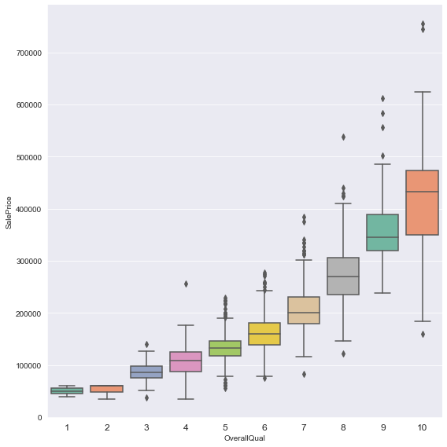

```python
chart = sns.catplot(data = train_df ,
                    x = 'OverallQual',
                    y='SalePrice',
                    kind='box',
                    height=8,
                    palette='Set2')

# Setting X labels
chart.set_xticklabels(fontweight='light',fontsize='large')
```

- Now, Overall quality itself seems to be a calculated metric but it definitely has a high correlation with SalePrice.
- Also, within the 10 possible values, the lower values (1,2 etc.) have a lesser spread as compared to higher values (9,10 etc.), which have a few outliers as well.

### SalePrice and YearBuilt

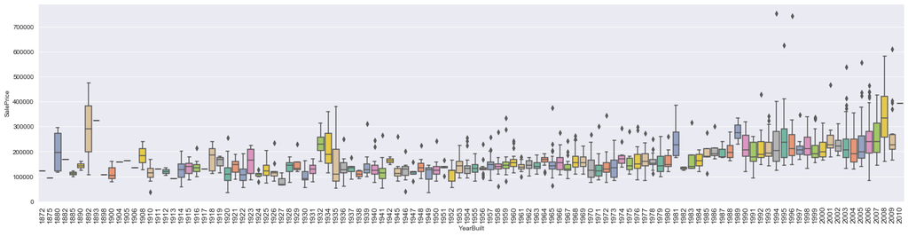

```python
chart = sns.catplot(data = train_df ,x = 'YearBuilt',y='SalePrice',
                    kind='box', # we want a boxplot
                    height=5,
                    aspect=4,
                    palette='Set2')

# Setting X labels
chart.set_xticklabels(fontweight='light',
                      fontsize='large',
                      rotation=90,
                      horizontalalignment='center')
```

- The Years range from 1872 to 2010. Post mid-30s, the general trend for median house price is going up. However, we don't know if the prices are adjusted for inflation. They most probably aren't.

### SalePrice and TotalBsmtSF

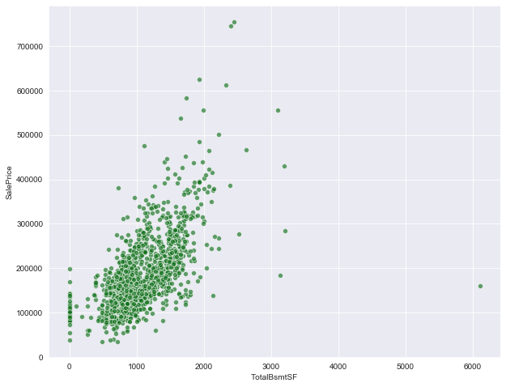

```python
plt.figure(figsize=(10,8))

sns.scatterplot(data = train_df ,
                x = 'TotalBsmtSF',
                y ='SalePrice',
                alpha = 0.65,
                color = 'g')
```

- The positive correlation is clear.
- Also, some outliers exist. Vis-a-vis: Point on the right with more than 6000 sq ft basement and a low SalePrice. (I wonder if this is a bunker!)

### SalePrice and GrLivArea

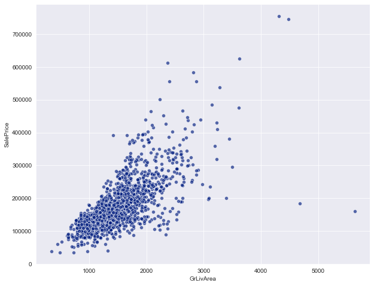

```python
plt.figure(figsize=(10,8))

sns.scatterplot(data = train_df ,
                x = 'GrLivArea',
                y ='SalePrice',
                alpha = 0.65,
                color = 'b')
```

- Overall, the positive corrrelation is quite obvious.
- There are 2 sets of outliers here:
  - The 2 observations on the bottom right, with >4000 sqft of GrLivArea but < 200k of SalePrice. We could consider drropping these points.
  - The 2 observations on the top right, with >4000 sqft of GrLivArea and >700k of SalePrice. Given, that these observations, although extreme, are still on the same trend as the other observations, we should keep them.

### SalePrice and GarageCars

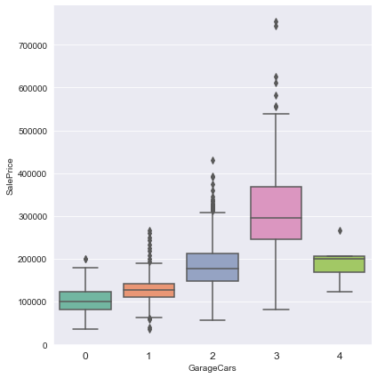

```python
chart = sns.catplot(data = train_df ,
                    x = 'GarageCars',
                    y='SalePrice',
                    kind='box',
                    height=6,
                    palette='Set2')

# Setting X labels
chart.set_xticklabels(fontweight='light',fontsize='large')
```

- The definition for GarageCars is "Size of garage in car capacity". You would expect SalePrice to keep on increasing with the garage size. However, median SalePrice decreases for the highest car capacity bucket. It could be because of a smaller sample size.
- Further, looking at the heatmap, the variables 'GarageArea' and 'GarageCars' seem to be highly correlated. This could lead to multicollinearity.
- Also, GarageCars seems to be correlated to OverallQual, indicating that it could be one of the factors involved in calculating OverallQual (assuming it is a calcualted variable).

# Feature engineering

## Removing IDs

- We need to remove the ID column since it is a unique identifier

```python
# Storing the IDs in a separate DF
train_df_IDs = train_df['Id']
test_df_IDs = test_df['Id']

# Dropping the columns
train_df.drop(['Id'], axis=1, inplace=True)
test_df.drop(['Id'], axis=1, inplace=True)

# Checking the shape of both DFs
print(train_df.shape)
print(test_df.shape)
```

```
(1460, 80)
(1459, 79)
```

- The numbers of columns have reduced by 1. ID has been removed.

## Normalizing SalePrice

- As we saw earlier, SalePrice is not normally distributed. ML models don't perform well with skewed data.
- In order to fix this, we will do a log transformation of SalePrice

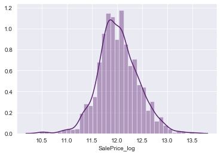

```python
# Log transforming SalePrice
train_df["SalePrice_log"] = np.log(train_df["SalePrice"])

# Plotting to vizualize the transformed variable
sns.distplot(train_df['SalePrice_log'], color="m", axlabel='SalePrice_log')
```

- SalePrice looks normally distributed now.

```python
# Dropping SalePrice_log as we will clean it in the next steps with pipeline
train_df = train_df.drop('SalePrice_log',axis=1)
```

## Removing Outliers

- We looked at the 2 observation on the 'GrLivArea - SalePrice' scatterplot. Let us remove them.

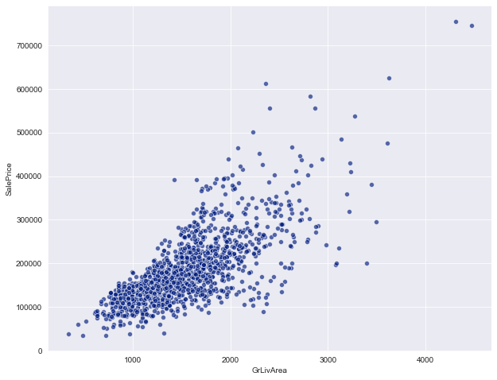

```python
# Dropping the outliers
train_df.drop(train_df[(train_df['GrLivArea']>4500) & (train_df['SalePrice']<300000)].index, inplace=True)

# Vizualizing the new scatterplot
plt.figure(figsize=(10,8))

sns.scatterplot(data = train_df ,
                x = 'GrLivArea',
                y ='SalePrice',
                alpha = 0.65,
                color = 'b')
```

## Missing Data

```python
# Separating Predictor and Labels
housing = train_df.drop("SalePrice",axis=1)
housing_labels = train_df['SalePrice']
```

```python
# calc total missing values
total_series = housing.isnull().sum().sort_values(ascending=False)

# calc percentages
perc_series = (housing.isnull().sum()/housing.isnull().count()).sort_values(ascending = False)

# concatenating total values and percentages
missing_data = pd.concat([total_series, perc_series*100], axis=1, keys=['Total #', 'Percent'])

# Looking at top 20 entries
missing_data.head(20)
```

|  | Total # | Percent |
| --- | --- | --- |
| PoolQC | 1452 | 99.588477 |
| MiscFeature | 1404 | 96.296296 |
| Alley | 1367 | 93.758573 |
| Fence | 1177 | 80.727023 |
| FireplaceQu | 690 | 47.325103 |
| LotFrontage | 259 | 17.764060 |
| GarageCond | 81 | 5.555556 |
| GarageType | 81 | 5.555556 |
| GarageYrBlt | 81 | 5.555556 |
| GarageFinish | 81 | 5.555556 |
| GarageQual | 81 | 5.555556 |
| BsmtExposure | 38 | 2.606310 |
| BsmtFinType2 | 38 | 2.606310 |
| BsmtFinType1 | 37 | 2.537723 |
| BsmtCond | 37 | 2.537723 |
| BsmtQual | 37 | 2.537723 |
| MasVnrArea | 8 | 0.548697 |
| MasVnrType | 8 | 0.548697 |
| Electrical | 1 | 0.068587 |
| LotConfig | 0 | 0.000000 |

- We have at least 19 columns with missing values.
- Additionally, there are some columns like MSSubClass,YrSold,MoSold,GarageYrBlt that should cateegorical but are listed as numeric

```python
# converting numeric columns to categorical
cols_int_to_str = ['MSSubClass','YrSold','MoSold','GarageYrBlt']

for col in cols_int_to_str:
    housing[col] = housing[col].astype(str)
    test_df[col] = test_df[col].astype(str)
```

```python
#housing.info()
```

- It is important to take a step back here and go through the data description. Obviously, we have 2 types of data points. Numeric and categorical. Further, for some categorical features, missing values can be filled with "None", whereas for some there is no clear intuition so we will go ahead with the most frequent value. Let's split the dataframe in 3 categories:
  - Numeric
  - Categorical to be filled with "None"
  - Categorical to be filled with most frequent

```python
numerics = ['int16', 'int32', 'int64', 'float16', 'float32', 'float64']

housing_num = housing.select_dtypes(include=numerics)
print(housing_num.shape)
```

```
(1458, 32)
```

```python
cat_none = ['GarageType', 'GarageFinish', 'GarageQual', 'GarageCond','BsmtQual', 'BsmtCond',\
            'BsmtExposure', 'BsmtFinType1', 'BsmtFinType2']

housing_cat_none = housing[cat_none]
housing_cat_freq = housing[(housing.columns.difference(cat_none)) & (housing.columns.difference(housing_num.columns))]
```

## Numerical Pipeline

- We will be creating 3 addtitional features:

  ```
    - Total_sqr_footage: The total sqr footage of the house i.e. basement + 1st floot+ 2nd floor.
    - Total_Bathrooms: Total number of bathrooms.
    - Total_porch_sf: Total sqr footage of the porch.
  ```

```python
from sklearn.base import BaseEstimator, TransformerMixin

# getting index of relevant columns instead of hardcoding
BsmtFinSF1_ix, BsmtFinSF2_ix, flr_1_ix, flr_2_ix,\
FullBath_ix, HalfBath_ix, BsmtFullBath_ix, BsmtHalfBath_ix,\
OpenPorchSF_ix, SsnPorch_ix, EnclosedPorch_ix, ScreenPorch_ix, WoodDeckSF_ix = [
    list(housing_num.columns).index(col)
    for col in ("BsmtFinSF1", "BsmtFinSF2","1stFlrSF","2ndFlrSF",\
                "FullBath","HalfBath","BsmtFullBath","BsmtHalfBath",\
                "OpenPorchSF","3SsnPorch","EnclosedPorch","ScreenPorch","WoodDeckSF")]

# Creating CombinedAttributesAdder class for creating the features
class CombinedAttributesAdder(BaseEstimator, TransformerMixin):
    def __init__(self, Total_sqr_footage = True, Total_Bathrooms=True,Total_porch_sf=True):
        self.Total_sqr_footage = Total_sqr_footage
        self.Total_Bathrooms = Total_Bathrooms
        self.Total_porch_sf = Total_porch_sf

    def fit(self, X, y=None):
        return self

    def transform(self, X, y=None):
        if self.Total_sqr_footage:
            Total_sqr_footage = X[:, BsmtFinSF1_ix] + X[:, BsmtFinSF2_ix] + X[:,flr_1_ix] + X[:,flr_2_ix]

        if self.Total_Bathrooms:
            Total_Bathrooms = X[:, FullBath_ix] + X[:, HalfBath_ix] + X[:,BsmtFullBath_ix] + X[:,BsmtHalfBath_ix]

        if self.Total_porch_sf:
            Total_porch_sf = X[:, OpenPorchSF_ix] + X[:, SsnPorch_ix] + X[:,EnclosedPorch_ix] + X[:,ScreenPorch_ix] + X[:,WoodDeckSF_ix]

        return np.c_[X, Total_sqr_footage,Total_Bathrooms,Total_porch_sf]
```

```python
# Importing necessary libraries
from sklearn.pipeline import Pipeline
from sklearn.preprocessing import StandardScaler
from sklearn.impute import SimpleImputer

# Creating numerical pipeline
num_pipeline = Pipeline([
        ('imputer', SimpleImputer(strategy="mean")), # To impute na values with mean
        ('attribs_adder', CombinedAttributesAdder()), # Create new features
        ('std_scaler', StandardScaler()), # Scale the numeric features
    ])
```

## Categorical Pipeline

```python
# Importing necessary libraries
from sklearn.preprocessing import OneHotEncoder

# Creating pipeline for categorical variables with missing value should be "None"
cat_pipeline_none = Pipeline([
        ('imputer', SimpleImputer(strategy='constant',fill_value='None')),
        ('encoder', OneHotEncoder(sparse=False,handle_unknown='ignore'))
    ])

# Creating pipeline for categorical variables where we plug missing value with most frequent value
cat_pipeline_freq = Pipeline([
        ('imputer', SimpleImputer(strategy='most_frequent')),
        ('encoder', OneHotEncoder(sparse=False,handle_unknown='ignore'))
    ])
```

## Creating Full pipeline

```python
# Importing ColumnTransformer
from sklearn.compose import ColumnTransformer

# Creating full pipeline to process numeric and categorical features
full_pipeline = ColumnTransformer(transformers=[
        ("num", num_pipeline, housing_num.columns),
        ("cat_none", cat_pipeline_none, housing_cat_none.columns),
        ("cat_freq", cat_pipeline_freq, housing_cat_freq.columns),
    ])

# Creating prepared data by passing the training set without labels
transf = full_pipeline.fit(housing)

housing_prepared = transf.transform(housing)
```

```python
# Checking the shape of the newly created data
housing_prepared.shape
```

```
(1458, 425)
```

```python
# Cleaning the test data
test_prepared = transf.transform(test_df)
```

```python
# Checking Test data's shape
test_prepared.shape
```

```
(1459, 425)
```

# Training Models

```python
# Defining CV Score function
def cv_score(score):
    rmse = np.sqrt(-score) # -score because we are using "neg_mean_squared_error" as our metric
    return (rmse)
```

## RandomForestRegressor

```python
%%time

# Import RandomForestRegressor
from sklearn.ensemble import RandomForestRegressor
from sklearn.model_selection import GridSearchCV
from sklearn.metrics import mean_squared_error as MSE

# Instantiate rf
rf = RandomForestRegressor(random_state = 42)

# Creating Parameter grid for GridSearch CV
params_rf = {
    'n_estimators': [100,500,1000], # No of trees
    'max_depth': [5,10,15], # maximum depth to explore
    'min_samples_split':[5,10,15], # minimum samples required for split
    'min_samples_leaf':[5,10,15], # minimum samples required at leaf
    'max_features': ['log2', 'auto', 'sqrt'] # number of features for the best split
}

# Instantiate grid_rf
grid_rf = GridSearchCV(estimator = rf, # regressor we want to use
                       param_grid = params_rf, # Hyperparameter space
                       scoring ='neg_mean_squared_error', # MSE will be performance metric
                       cv = 3, # #of folds
                       verbose = 1,
                       n_jobs = -1) # use all cores

# fit the model
grid_rf.fit(housing_prepared,housing_labels)
```

```
Fitting 3 folds for each of 243 candidates, totalling 729 fits
```

```
[Parallel(n_jobs=-1)]: Using backend LokyBackend with 12 concurrent workers.
[Parallel(n_jobs=-1)]: Done  26 tasks      | elapsed:    7.5s
[Parallel(n_jobs=-1)]: Done 176 tasks      | elapsed:  1.5min
[Parallel(n_jobs=-1)]: Done 426 tasks      | elapsed:  3.4min
[Parallel(n_jobs=-1)]: Done 729 out of 729 | elapsed:  5.6min finished
```

```
CPU times: user 12.6 s, sys: 389 ms, total: 13 s
Wall time: 5min 46s
```

```
GridSearchCV(cv=3, error_score='raise-deprecating',
             estimator=RandomForestRegressor(bootstrap=True, criterion='mse',
                                             max_depth=None,
                                             max_features='auto',
                                             max_leaf_nodes=None,
                                             min_impurity_decrease=0.0,
                                             min_impurity_split=None,
                                             min_samples_leaf=1,
                                             min_samples_split=2,
                                             min_weight_fraction_leaf=0.0,
                                             n_estimators='warn', n_jobs=None,
                                             oob_score=False, random_state=42,
                                             verbose=0, warm_start=False),
             iid='warn', n_jobs=-1,
             param_grid={'max_depth': [5, 10, 15],
                         'max_features': ['log2', 'auto', 'sqrt'],
                         'min_samples_leaf': [5, 10, 15],
                         'min_samples_split': [5, 10, 15],
                         'n_estimators': [100, 500, 1000]},
             pre_dispatch='2*n_jobs', refit=True, return_train_score=False,
             scoring='neg_mean_squared_error', verbose=1)
```

```python
print('CV Score for best RandomForestRegressor model: {:.2f}'.format(cv_score(grid_rf.best_score_)))
```

```
CV Score for best RandomForestRegressor model: 27876.07
```

```python
# Store the best model
best_model_RF = grid_rf.best_estimator_
```

## Gradient Boosting

```python
%%time

# Importing the necessary package
from sklearn.ensemble import GradientBoostingRegressor

# Instantiate the Gradient Boosting Regressor
gbr = GradientBoostingRegressor(subsample = 0.9,
                                max_features = 0.75,
                                random_state = 42,
                                warm_start = True,
                                learning_rate= 0.01)

# Creating Parameter grid for GridSearch CV
params_gbr = {
    'n_estimators': [1000,4000,8000],
    'max_depth': [2,5,8],
    'min_samples_split':[5,15],
    'min_samples_leaf':[5,15],
    'max_features': ['log2', 'auto', 'sqrt']
}

# Instantiate grid search using GradientBoostingRegressor
grid_gbr = GridSearchCV(estimator = gbr, # regressor we want to use
                       param_grid = params_gbr, # Hyperparameter space
                       scoring ='neg_mean_squared_error',
                       cv = 3, # No of folds
                       verbose = 1,
                       n_jobs = -1) # use all cores

# fit the model
grid_gbr.fit(housing_prepared,housing_labels)
```

```
Fitting 3 folds for each of 108 candidates, totalling 324 fits
```

```
[Parallel(n_jobs=-1)]: Using backend LokyBackend with 12 concurrent workers.
[Parallel(n_jobs=-1)]: Done  26 tasks      | elapsed:   13.7s
[Parallel(n_jobs=-1)]: Done 176 tasks      | elapsed: 17.2min
[Parallel(n_jobs=-1)]: Done 324 out of 324 | elapsed: 42.0min finished
```

```
CPU times: user 6.71 s, sys: 248 ms, total: 6.96 s
Wall time: 42min 3s
```

```
GridSearchCV(cv=3, error_score='raise-deprecating',
             estimator=GradientBoostingRegressor(alpha=0.9,
                                                 criterion='friedman_mse',
                                                 init=None, learning_rate=0.01,
                                                 loss='ls', max_depth=3,
                                                 max_features=0.75,
                                                 max_leaf_nodes=None,
                                                 min_impurity_decrease=0.0,
                                                 min_impurity_split=None,
                                                 min_samples_leaf=1,
                                                 min_samples_split=2,
                                                 min_weight_fraction_leaf=0.0,
                                                 n_estimators=100,
                                                 n_ite...
                                                 random_state=42, subsample=0.9,
                                                 tol=0.0001,
                                                 validation_fraction=0.1,
                                                 verbose=0, warm_start=True),
             iid='warn', n_jobs=-1,
             param_grid={'max_depth': [2, 5, 8],
                         'max_features': ['log2', 'auto', 'sqrt'],
                         'min_samples_leaf': [5, 15],
                         'min_samples_split': [5, 15],
                         'n_estimators': [1000, 4000, 8000]},
             pre_dispatch='2*n_jobs', refit=True, return_train_score=False,
             scoring='neg_mean_squared_error', verbose=1)
```

```python
print('CV Score for best GradientBoostingRegressor model: {:.2f}'.format(cv_score(grid_gbr.best_score_)))
```

```
CV Score for best GradientBoostingRegressor model: 21914.88
```

```python
# Store the best model
best_model_GBR = grid_gbr.best_estimator_
```

```python
best_model_GBR
```

```
GradientBoostingRegressor(alpha=0.9, criterion='friedman_mse', init=None,
                          learning_rate=0.01, loss='ls', max_depth=2,
                          max_features='sqrt', max_leaf_nodes=None,
                          min_impurity_decrease=0.0, min_impurity_split=None,
                          min_samples_leaf=5, min_samples_split=5,
                          min_weight_fraction_leaf=0.0, n_estimators=8000,
                          n_iter_no_change=None, presort='auto',
                          random_state=42, subsample=0.9, tol=0.0001,
                          validation_fraction=0.1, verbose=0, warm_start=True)
```

## Ridge Regression

```python
%%time

from sklearn.linear_model import Ridge

# Instantiate the Ridge Regressor
ridge = Ridge(random_state=42)

# Creating Parameter grid for GridSearch CV
params_ridge = {
    'alpha': [1e-15, 1e-10, 1e-8, 9e-4, 7e-4, 5e-4, 3e-4, 1e-4, 1e-3, 5e-2, 1e-2, 0.1, 0.3, 1, 3, 5, 10, 15, 18, 20, 30, 50, 75, 100],
    'solver': ['auto','saga','sag','cholesky']
}

# Instantiate grid search using GradientBoostingRegressor
grid_ridge = GridSearchCV(estimator = ridge, # regressor we want to use
                       param_grid = params_ridge, # Hyperparameter space
                       scoring ='neg_mean_squared_error',
                       cv = 3, # No of folds
                       verbose = 1,
                       n_jobs = -1) # use all cores

# fit the model
grid_ridge.fit(housing_prepared,housing_labels)
```

```
Fitting 3 folds for each of 96 candidates, totalling 288 fits
```

```
[Parallel(n_jobs=-1)]: Using backend LokyBackend with 12 concurrent workers.
[Parallel(n_jobs=-1)]: Done  26 tasks      | elapsed:    3.7s
[Parallel(n_jobs=-1)]: Done 176 tasks      | elapsed:   26.1s
[Parallel(n_jobs=-1)]: Done 288 out of 288 | elapsed:   30.4s finished
```

```
GridSearchCV(cv=3, error_score='raise-deprecating',
             estimator=Ridge(alpha=1.0, copy_X=True, fit_intercept=True,
                             max_iter=None, normalize=False, random_state=42,
                             solver='auto', tol=0.001),
             iid='warn', n_jobs=-1,
             param_grid={'alpha': [1e-15, 1e-10, 1e-08, 0.0009, 0.0007, 0.0005,
                                   0.0003, 0.0001, 0.001, 0.05, 0.01, 0.1, 0.3,
                                   1, 3, 5, 10, 15, 18, 20, 30, 50, 75, 100],
                         'solver': ['auto', 'saga', 'sag', 'cholesky']},
             pre_dispatch='2*n_jobs', refit=True, return_train_score=False,
             scoring='neg_mean_squared_error', verbose=1)
```

```python
print('CV Score for best RidgeRegressor model: {:.2f}'.format(cv_score(grid_ridge.best_score_)))
```

```
CV Score for best RidgeRegressor model: 25304.48
```

```python
# Store the best model
best_model_ridge = grid_ridge.best_estimator_
```

## ElasticNet Regression

```python
%%time
from sklearn.linear_model import ElasticNet

# Instantiate the Ridge Regressor
elastic = ElasticNet(random_state=42)

# Creating Parameter grid for GridSearch CV
params_elastic = {
    'alpha': [1e-15, 1e-10, 1e-8, 9e-4, 7e-4, 5e-4, 3e-4, 1e-4, 1e-3, 5e-2, 1e-2, 0.1, 0.3, 1, 3, 5, 10, 15, 18, 20, 30, 50, 75, 100],
    'l1_ratio': [0.001,0.01,0.1,0.3,0.5,0.8,0.9]
}

# Instantiate grid search using GradientBoostingRegressor
grid_elastic = GridSearchCV(estimator = elastic, # regressor we want to use
                       param_grid = params_elastic, # Hyperparameter space
                       scoring ='neg_mean_squared_error',
                       cv = 3, # No of folds
                       verbose = 1,
                       n_jobs = -1) # use all cores

# fit the model
grid_elastic.fit(housing_prepared,housing_labels)
```

```
[Parallel(n_jobs=-1)]: Using backend LokyBackend with 12 concurrent workers.
```

```
Fitting 3 folds for each of 168 candidates, totalling 504 fits
```

```
[Parallel(n_jobs=-1)]: Done  26 tasks      | elapsed:    8.2s
[Parallel(n_jobs=-1)]: Done 176 tasks      | elapsed:   31.0s
[Parallel(n_jobs=-1)]: Done 504 out of 504 | elapsed:   42.2s finished
```

```
CPU times: user 4.04 s, sys: 258 ms, total: 4.3 s
Wall time: 42.4 s
```

```
GridSearchCV(cv=3, error_score='raise-deprecating',
             estimator=ElasticNet(alpha=1.0, copy_X=True, fit_intercept=True,
                                  l1_ratio=0.5, max_iter=1000, normalize=False,
                                  positive=False, precompute=False,
                                  random_state=42, selection='cyclic',
                                  tol=0.0001, warm_start=False),
             iid='warn', n_jobs=-1,
             param_grid={'alpha': [1e-15, 1e-10, 1e-08, 0.0009, 0.0007, 0.0005,
                                   0.0003, 0.0001, 0.001, 0.05, 0.01, 0.1, 0.3,
                                   1, 3, 5, 10, 15, 18, 20, 30, 50, 75, 100],
                         'l1_ratio': [0.001, 0.01, 0.1, 0.3, 0.5, 0.8, 0.9]},
             pre_dispatch='2*n_jobs', refit=True, return_train_score=False,
             scoring='neg_mean_squared_error', verbose=1)
```

```python
print('CV Score for best ElasticNet model: {:.2f}'.format(cv_score(grid_elastic.best_score_)))
```

```
CV Score for best ElasticNet model: 25295.85
```

```python
# Store the best model
best_model_elastic = grid_elastic.best_estimator_
```

## SVM

```python
%%time
from sklearn.svm import SVR

# Instantiate the SVM Regressor
svr = SVR()

# Creating Parameter grid for GridSearch CV
params_svr = {
    'kernel': ['poly'], # we want a polynomial kernel
    'degree': [5,8], # degrees to test
    'gamma':[0.01,0.05,0.1],
    'epsilon': [0.1,0.005,1.5,3],
    'coef0':[2,3,5], # since we are selecting a polynomial kernel
    'C': [1,15,20,30], # Penalty parameter
    'tol':[1e-7,1e-6,1e-5] # Tolerance for stopping
}

# Instantiate grid search using GradientBoostingRegressor
grid_svr = GridSearchCV(estimator = svr, # regressor we want to use
                       param_grid = params_svr, # Hyperparameter space
                       scoring ='neg_mean_squared_error',
                       cv = 3, # No. of folds
                       verbose = 1,
                       n_jobs = -1) # use all cores

# fit the model
grid_svr.fit(housing_prepared,housing_labels)
```

```
Fitting 3 folds for each of 864 candidates, totalling 2592 fits
```

```
[Parallel(n_jobs=-1)]: Using backend LokyBackend with 12 concurrent workers.
[Parallel(n_jobs=-1)]: Done  26 tasks      | elapsed:    5.7s
[Parallel(n_jobs=-1)]: Done 176 tasks      | elapsed:   30.4s
[Parallel(n_jobs=-1)]: Done 426 tasks      | elapsed:  1.2min
[Parallel(n_jobs=-1)]: Done 776 tasks      | elapsed:  2.3min
[Parallel(n_jobs=-1)]: Done 1226 tasks      | elapsed:  3.9min
[Parallel(n_jobs=-1)]: Done 1776 tasks      | elapsed:  5.7min
[Parallel(n_jobs=-1)]: Done 2426 tasks      | elapsed:  7.8min
[Parallel(n_jobs=-1)]: Done 2592 out of 2592 | elapsed:  8.4min finished
```

```
CPU times: user 10.9 s, sys: 777 ms, total: 11.7 s
Wall time: 8min 25s
```

```
GridSearchCV(cv=3, error_score='raise-deprecating',
             estimator=SVR(C=1.0, cache_size=200, coef0=0.0, degree=3,
                           epsilon=0.1, gamma='auto_deprecated', kernel='rbf',
                           max_iter=-1, shrinking=True, tol=0.001,
                           verbose=False),
             iid='warn', n_jobs=-1,
             param_grid={'C': [1, 15, 20, 30], 'coef0': [2, 3, 5],
                         'degree': [5, 8], 'epsilon': [0.1, 0.005, 1.5, 3],
                         'gamma': [0.01, 0.05, 0.1], 'kernel': ['poly'],
                         'tol': [1e-07, 1e-06, 1e-05]},
             pre_dispatch='2*n_jobs', refit=True, return_train_score=False,
             scoring='neg_mean_squared_error', verbose=1)
```

```python
print('CV Score for best SVM model: {:.2f}'.format(cv_score(grid_svr.best_score_)))
```

```
CV Score for best SVM model: 20215.16
```

```python
# Store the best model
best_model_svr = grid_svr.best_estimator_
```

## XGBoost

```python
%%time
import xgboost as xgb

# Instantiate the SVM Regressor
xgbr = xgb.XGBRegressor(learning_rate=0.01,objective='reg:linear',booster='gbtree')

# Creating Parameter grid for GridSearch CV
params_xgb = {
    'n_estimators': [8000,10000], #4000,12000
    'max_depth': [2],
    'gamma':[0.1,0.2], # Minimum loss reduction to create new tree split ,0.5,0.9
    'subsample':[0.7],
    'reg_lambda':[0.1],
    'reg_alpha':[0.1,0.8]
}

# Instantiate grid search using GradientBoostingRegressor
grid_xgb = GridSearchCV(estimator = xgbr, # regressor we want to use
                       param_grid = params_xgb, # Hyperparameter space
                       scoring ='neg_mean_squared_error',
                       cv = 3, # No. of folds
                       verbose = 1,
                       n_jobs = -1) # use all cores

# fit the model
grid_xgb.fit(housing_prepared,housing_labels)
```

```
Fitting 3 folds for each of 8 candidates, totalling 24 fits
```

```
[Parallel(n_jobs=-1)]: Using backend LokyBackend with 12 concurrent workers.
[Parallel(n_jobs=-1)]: Done  24 out of  24 | elapsed:  9.0min finished
```

```
[12:35:11] WARNING: src/objective/regression_obj.cu:152: reg:linear is now deprecated in favor of reg:squarederror.
CPU times: user 2min 14s, sys: 184 ms, total: 2min 14s
Wall time: 11min 15s
```

```
GridSearchCV(cv=3, error_score='raise-deprecating',
             estimator=XGBRegressor(base_score=0.5, booster='gbtree',
                                    colsample_bylevel=1, colsample_bynode=1,
                                    colsample_bytree=1, gamma=0,
                                    importance_type='gain', learning_rate=0.01,
                                    max_delta_step=0, max_depth=3,
                                    min_child_weight=1, missing=None,
                                    n_estimators=100, n_jobs=1, nthread=None,
                                    objective='reg:linear', random_state=0,
                                    reg_alpha=0, reg_lambda=1,
                                    scale_pos_weight=1, seed=None, silent=None,
                                    subsample=1, verbosity=1),
             iid='warn', n_jobs=-1,
             param_grid={'gamma': [0.1, 0.2], 'max_depth': [2],
                         'n_estimators': [8000, 10000], 'reg_alpha': [0.1, 0.8],
                         'reg_lambda': [0.1], 'subsample': [0.7]},
             pre_dispatch='2*n_jobs', refit=True, return_train_score=False,
             scoring='neg_mean_squared_error', verbose=1)
```

```python
print('CV Score for best SVM model: {:.2f}'.format(cv_score(grid_xgb.best_score_)))
```

```
CV Score for best SVM model: 22065.26
```

```python
# Store the best model
best_model_xgb = grid_xgb.best_estimator_
```

## Ensemble

```python
from sklearn.ensemble import VotingRegressor

voting_reg = VotingRegressor(
    estimators=[('rf', best_model_RF), ('gbr', best_model_GBR), ('elastic', best_model_elastic),
               ('ridge',best_model_ridge),('svr',best_model_svr),('xgb',best_model_xgb)])
```

[output not shown]

[output not shown]

```python
from sklearn.model_selection import cross_val_score

scores = cross_val_score(voting_reg, housing_prepared, housing_labels,
                         scoring="neg_mean_squared_error", cv=10)
```

[output not shown]

[output not shown]

[output not shown]

[output not shown]

[output not shown]

[output not shown]

[output not shown]

[output not shown]

[output not shown]

[output not shown]

```python
voting_reg_score = np.sqrt(-scores)
print(voting_reg_score.mean())
```

```
21051.875329455892
```

## Predicting

```python
# Fit the Ensemble model to the training data
voting_reg.fit(housing_prepared, housing_labels)

# Predict on test data
pred = voting_reg.predict(test_prepared)
```

```
[14:43:49] WARNING: src/objective/regression_obj.cu:152: reg:linear is now deprecated in favor of reg:squarederror.
```

```python
# Creating a dataframe
preds = pd.DataFrame(pd.concat([test_df_IDs,pd.Series(pred)],axis=1),
                     index=None)

# Renaming the columns
preds.rename(columns={0: "SalePrice"},inplace=True)
```

```python
# Inspecting the final prediction dataframe
preds.head()
```

|  | Id | SalePrice |
| --- | --- | --- |
| 0 | 1461 | 121804.161120 |
| 1 | 1462 | 163112.543411 |
| 2 | 1463 | 188093.310283 |
| 3 | 1464 | 196341.335004 |
| 4 | 1465 | 193838.924887 |

```python
# Saving to CSV
preds.to_csv('submissions.csv')
```

# Resources:

Kernels: The following Kernels have been immensely helpful and shaped my approach towards the problem!

1. [Lavanya Shukla's Kernel](https://www.kaggle.com/lavanyashukla01/how-i-made-top-0-3-on-a-kaggle-competition)
2. [Serigne's Stacked Regressions Kernel](https://www.kaggle.com/serigne/stacked-regressions-top-4-on-leaderboard)
3. [Pedro Marcelino's EDA Kernel](https://www.kaggle.com/pmarcelino/comprehensive-data-exploration-with-python)

Other online resoruces:

1. [Rotating labels:](https://www.drawingfromdata.com/how-to-rotate-axis-labels-in-seaborn-and-matplotlib)
2. [Getting feature names after one-hot encoder:](https://stackoverflow.com/questions/54646709/sklearn-pipeline-get-feature-name-after-onehotencode-in-columntransformer/54648023)
3. [Random Forest Vs Gradient boosting:](https://stats.stackexchange.com/questions/173390/gradient-boosting-tree-vs-random-forest)